# BSAN2204

Tutorial 7

Exploratory Analysis

Descriptive Statistics and Data Visualisation

## Lecture recap: Exploratory Analysis

Exploratory analysis refers to the process of summarising data in order to uncover patterns and relationships prior to formal modelling.

At this stage of any business analytics project, the aim is to understand the available data and develop some preliminary insights about key variables of interest in a data set.

The data exploration part of your *Predictive Analytics Report (A2)* needs to include a **carefully curated selection** of descriptive statistics and data visualisations.

“Carefully curated” means making some of your own *justified* decisions about which variables, statistics and relationships to analyse and include in your report.

## Continuing your `.Rmd` report

To run the code contained in this tutorial, you will the `R` objects set up from the previous tutorials. These are objects should be created within the subsections of the report introduction.

As a minimum to be able to complete this tutorial, you need to have loaded the `MSD.Rdata` as an object called `MSD`.

Ideally, you should by now have a completely pre-processed data frame called `training_data` ready for analysis. If you do not, then return to the notes from previous sessions.

## Today’s goals

Today we will aim to develop the code in your `.Rmd` file for:

1. Measures of central tendency for all continuous variables
2. Measures of counts/proportions for all categorical variables
3. Carefully curated and justified bivariate statistics
4. At least one univariate graph, and one bivariate graph which are carefully curated and designed for impact and clear interpretation
5. Highlights of key insights, demonstrating a high level of understanding of the analysis.

## Descriptive Statistics

Descriptive statistics can be broken down into two types: *univariate* and *bivariate* statistics.

Univariate statistics include measures of central tendency (for continuous variables) and measures of counts/proportions (for categorical variables). These are considered descriptive univariate statistics as they consider the values of individual variables.

Descriptive *bivariate* statistics consider the relationship between two variables (e.g., *t* tests for differences in means, $\chi^2$ tests for associations in counts).

## Measures of central tendency

The mean (average), standard deviation and skewness/kurtosis are useful measures of central tendency for continuous variables.

Base `R` has functions for the mean and standard deviation, but there is no base `R` function for skewness or kurtosis so we must rely on additional packages for those.

These are univariate statistics for continuous variables. The `describe()` function from the `psych` package in `R` provides the easiest way to gather a collection of the most commonly used descriptive statistics in a conveniently structured data frame that can be piped directly into `kable()` for reporting.

## Continuous variables

Continuous variables are measurable quantities that can take on any value within a range. In the `MSD` these are all of the variables which are stored as `numeric` or `integer` values. We describe these variables using univariate statistics, as well as relationships among these variables two at a time using bivariate statistics.

The MSD contains many continuous variables, but not all of them are suitable for summarising. For example, we do not want to include the `_______id` variables.

## Selecting variables

A good way to select which variables to include is to use a character vector of variable names:

```r
varlist <- c(var1, var2, ..., varN)
```

A good way to select which statistics to include is to use a character vector of the statistic names:

```r
stats <- c(stat1, stat2, ..., statN)
```

Basic R skills: The above code will not work *as is* (it does not contain the correct variable names). Satisfy yourself that you truly understand the difference between the above code, and the code on the next slides.

## Create a variable list

**You** should describe “all continuous variables” but for now we will work with just *some* (3) of the variables.

```r
varlist <- c("song_hotttnesss", "tempo", "loudness")
```

The short list used in the tutorial is used simply to to ensure the tables fit neatly on the slide (as well as to leave you with some work to do in adopting the code to your project!).

A clear justification for which continuous variables to include in your report is important, because it signals that variable selection is not arbitrary but grounded in the purpose and constraints of the analysis.

## Selecting variables

Some of the Million Song Dataset variables are **easy to observe in practice** (e.g., duration, tempo) because they can be measured directly from audio or metadata. Other variables (e.g., artist familiarity or hotttnesss) are **proprietary and algorithmically derived**, making them hard to obtain for new or external songs later in your report when developing predictive models.

Whilst you can describe all variables in the data at this stage of the report using descriptive statistics, it will later become important to focus on variables which can be reliably used in predictive models.

## Using `describe()`

`describe()` generates a data frame of descriptive statistics. The rows of the output data frame correspond to each of the variables you decide to include, and the columns of the output data frame contains 13 descriptive statistics. We do not need to describe all the variables, now do we need to report all 13 statistics!

```r
library(psych)
describe(training_data)
```

```
                   vars     n       mean         sd     median    trimmed        mad     min        max      range  skew kurtosis       se
artist_name*          1 10000    4083.45    2351.22    4083.00    4082.77    3002.26    1.00    8170.00    8169.00  0.00    -1.20    23.51
artist_7digitalid     2  9973  126433.50  145011.05   62223.00  100546.36   84537.85    6.00  796571.00  796565.00  1.38     1.21  1452.07
artist_familiarity    3  9972       0.56       0.14       0.56       0.56       0.12    0.01       1.00       0.99 -0.32     1.02     0.00
artist_hotttnesss     4  9480       0.40       0.09       0.39       0.40       0.08    0.01       1.02       1.01  0.61     2.54     0.00
duration              5 10000     248.22     119.96     228.09     235.39      75.52    4.00    2388.53    2384.54  3.42    32.47     1.20
end_of_fade_in        6  6861       1.19       2.33       0.33       0.68       0.26    0.06      50.61      50.55  5.92    64.32     0.03
key*                  7 10000       6.38       3.61       7.00       6.36       4.45    1.00      12.00      11.00 -0.03    -1.31     0.04
loudness              8 10000     -10.09       5.15      -8.87      -9.45       4.29  -41.42       0.05      41.47 -1.36     2.57     0.05
mode*                 9 10000       1.66       0.47       2.00       1.70       0.00    1.00       2.00       1.00 -0.69    -1.52     0.00
release*             10 10000    4648.43    2681.94    4649.00    4649.68    3444.82    1.00    9296.00    9295.00  0.00    -1.20    26.82
release_7digitalid   11 10000  381687.57  237356.35  355655.00  376646.06  294676.39   29.00  823427.00  823398.00  0.14    -1.16  2373.56
song_hotttnesss      12  4578       0.45       0.16       0.45       0.45       0.19    0.19       1.00       0.81  0.35    -0.65     0.00
start_of_fade_out    13 10000     239.22     117.02     219.14     226.42      74.10    4.00    2361.04    2357.04  3.39    32.18     1.17
tempo                14  9964     124.81      34.27     122.98     122.75      34.29   15.54     255.57     240.03  0.54     0.35     0.34
time_signature*      15  9989       2.70       0.86       3.00       2.75       0.00    1.00       5.00       4.00 -0.50     0.67     0.01
title*               16 10000    4892.02    2821.28    4884.50    4891.57    3622.73    1.00    9789.00    9788.00  0.00    -1.20    28.21
track_7digitalid     17 10000 4233688.30 2636571.65 3969963.00 4181025.63 3297763.49  303.00 9088808.00 9088505.00  0.13    -1.17 26365.72
year                 18  5164    1998.52      10.99    2002.00    2000.48       7.41 1927.00    2010.00      83.00 -1.79     3.82     0.15
```

## Create a statistics list

The measures of central tendency we should include in our output table should be the number of observations, mean, standard deviation, skewness and kurtosis.

```r
stats <- c("n", "mean", "sd", "skew", "kurtosis")
```

With this character vector in place, we can used it to refer to the column names of the data frame output from `describe()` to carefully curate which statistics report.

We can also use the variable list created earlier to refer to which rows from the `training_data` data frame we want to be included in the `describe()` function.

## Building the table with `kable()`

The `knitr` package which we loaded during the YAML contains the the `kable()` function. As `kable()` requires a data frame as its input, the output from `describe()` can be piped directly to it. Before rendering the table, it can also be useful to pipe the data frame through a rounding function to control how many decimal places are reported (here we have chosen 3 decimals).

```r
describe(training_data[ , varlist])[, stats] |>
  round(3) |>
  kable(caption = "Descriptive Statistics for Continuous Variables in the MSD")
```

Descriptive Statistics for Continuous Variables in the MSD

|  | n | mean | sd | skew | kurtosis |
| --- | --- | --- | --- | --- | --- |
| song_hotttnesss | 4578 | 0.455 | 0.164 | 0.345 | -0.653 |
| tempo | 9964 | 124.805 | 34.271 | 0.544 | 0.353 |
| loudness | 10000 | -10.088 | 5.152 | -1.364 | 2.573 |

You **should not** echo code for building tables.

## Refresher on the `|>` operator

The code examples on the previous slides show examples of the `|>` operator being used to improve the readability of the code (i.e., human readability).

Compare how you would “read” each of the following:

```r
describe(training_data[ , varlist])[, stats] |>
  kable(caption = "Descriptive Statistics for Continuous Variables in the MSD")
```

versus

```r
kable(round(describe(training_data[, varlist])[ , stats], 3),
      caption = "Descriptive Statistics for Continuous Variables in the MSD")
```

## Reading `(a) |> (b)` versus `(b(a))`

Piped

```r
describe(training_data[ , varlist])[, stats] |>
  kable(caption = "Descriptive Statistics for Continuous Variables in the MSD")
```

Logic:

“Take the output from `describe()` and pipe it to `kable()` (for formatting) and then add a caption.

Nested

```r
kable(round(describe(training_data[, varlist])[ , stats], 3),
      caption = "Descriptive Statistics for Continuous Variables in the MSD")
```

Logic:

“Use `kable()` (for formatting) on the rounded output from `describe()`, to 3 decimal places and then add a caption.

## Inline reporting

We often want to refer to values in text, but which method should we use?

Method 1 (no inline coding)

[output not shown]

Method 2 (calculate):

```
The average level of song hotness in the data is `r mean(na.omit(song_hotttnesss)) |> round(3)`.
```

## Testing for statistical significance

The differences in two means is tested using a *t*-test. If the *p*-value of this test is significant, then maybe there is something interesting to explore later, e.g., including an interaction effect in a regression model later in the *Predictive Analytics Report (A2)*.

```markdown
The *p*-value of the difference in the mean of `duration` between songs in minor vs major is
`r t.test(duration ~ mode, data = training_data)$p.value |> formatC(format = 'f', digits = 3)`.
```

Rendered text:

The *p*-value of the difference in the mean of `duration` between songs in minor vs major is 0.000.

## Measures of counts/proportions

Counts/proportions are univariate statistics for categorical variables.

Base `R` has the function `table()` to tabulate of the counts of the levels of a categorical variable, or contingency tables for two categorical variables.

Significance tests for associations among categorical variables can be calculated based on contingecy tables using `chisq.test()`

## Categorical variables

Categorical variables are variables that represent groups, categories, or labels rather than numeric quantities.

The variables in the `MSD` which are categorical are those factor variables, whose levels we labelled in a previous session. `year` is also categorical, but it makes more sense treat it as continuous given how many “levels”.

Year could be recoded into decades or according to some other schema. What would you do?

## Using `table()` for counts

When one categorical variable is supplied to `table()` it produces a frequency table. For example:

```r
table(time_signature) |>
  kable()
```

| time_signature | Freq |
| --- | --- |
| Unknown | 1414 |
| 3/4 (Triple) | 1178 |
| 4/4 (Common) | 6627 |
| 5/4 (Quintuple) | 544 |
| 7/4 (Septuple) | 226 |

## Reporting counts

`mode` only has two levels, so it is probably sufficient to just summarise its values using either inline visually (rather than in a table).

```
Out of the `r nrow(training_data)` songs in the training data `r unname(table(mode)['minor'])` songs are in a
minor scale whilst `r unname(table(mode)['major'])` are in a major scale.
```

Rendered text:

Out of the 10000 songs in the training data 3367 songs are in a minor scale whilst 6633 are in a major scale.

## Transposing data

By default, `kable()` will stack counts vertically. This does not present well for variables with many levels.

To rotate the table orientation, we can pipe the table object through to the transpose function `t()` before piping to `kable()`.

```r
table(key) |>
       t() |>
  kable(caption = "Count of key in the MSD")
```

Count of key in the MSD

| C | C#/Db | D | D#/Eb | E | F | F#/Gb | G | G#/Ab | A | A#/Bb | B |
| --- | --- | --- | --- | --- | --- | --- | --- | --- | --- | --- | --- |
| 1217 | 800 | 1103 | 320 | 778 | 728 | 572 | 1311 | 515 | 1103 | 694 | 859 |

## Using `table()` for contingency tables

Contingency tables can useful to see whether there are patterns among categorical variables, although when the number of categories is more than about 3 for at least one of the variables such tables may be difficult to interpret.

See for example:

```r
table(mode, key) |>
  kable(caption = "Contingency table of mode and key in the MSD")
```

Contingency table of mode and key in the MSD

|  | C | C#/Db | D | D#/Eb | E | F | F#/Gb | G | G#/Ab | A | A#/Bb | B |
| --- | --- | --- | --- | --- | --- | --- | --- | --- | --- | --- | --- | --- |
| minor | 188 | 220 | 214 | 113 | 396 | 263 | 278 | 226 | 122 | 458 | 370 | 519 |
| major | 1029 | 580 | 889 | 207 | 382 | 465 | 294 | 1085 | 393 | 645 | 324 | 340 |

## $\chi^2$-test for association

We can check whether there is a relationship between `key` and `mode` by piping the contingency table to `chisq.test()` and reporting the *p*-value.

```markdown
The *p*-value of the test of independence between key and number of mode is
`r chisq.test(table(mode, key))$p.value |>
  formatC(format = 'f', digits = 3)`.
```

Rendered text:

The *p*-value of the test of independence between key and number of mode is 0.000.

## Data Visualisation

For the *Predictive Analytics Report (A2)* you should include at least one univariate visualisation, and one bivariate visualisation. The types of visualisation you choose should carefully selected (i.e., justified) and designed for impact and clear interpretation.

It is possible to combine multiple graphs into a single visualisation.

## Univariate graphs

These are graphs which plot *one variable*. For continuous data, the simplest graph is a histogram which is made using the base `R` `hist()` function, for example:

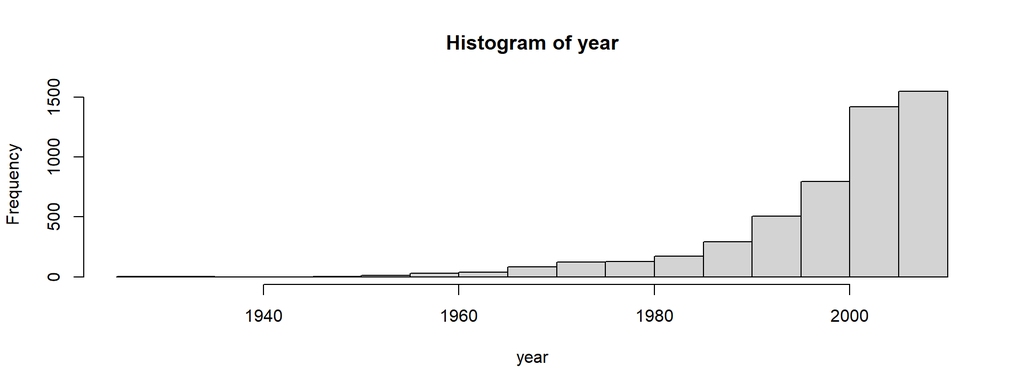

```r
hist(year)
```

## Formatting plots

The formatting of visualisations is done by setting options.

The bin width of each bar using `breaks =`, adjusting the colours of the bars using `col =`, setting the main plot title with `main =` and adding text to the x and y axes using `xlab =` and `ylab =`.

```r
hist(
  year,
  breaks = 20,
  col = "skyblue",
  border = "white",
  main = "Distribution of Song Hotttnesss",
  xlab = "Song Hotttnesss Score",
  ylab = "Frequency"
)
```

You **should not** echo plotting code.

## Other plot formatting options

In the `` ```{r setup, include=FALSE} `` chunk, we can also set default settings that apply to all plots within the document. For example, to ensure that all plots fill the available width of space we can set `opts_chunk$set(out.width = "100%")`

Within individual `R` code chunks for plots further settings can be used to control plot appearance *within that chunk*.

The most useful of is `mfrow` which allows you to output several graphs in one visualisation. This is recommended for combining together multiple graphs of the same or similar type acros multiple pairs of variables.

## Using `mfrow` (example, lacking formatting)

The following demonstrates using `par(mfrow = )` to control the layout of the plot window to create a multi-graph visualisation.

```r
par(mfrow = c(2,2))
hist(year)
hist(tempo)
plot(artist_hotttnesss, song_hotttnesss)
table(key) |> barplot(cex.names = 0.5, las = 2)
```

Such a layout is most useful when you do not intend to focus or give emphasis to any one particular graph. Plots of greater importance (those which a key insight might be drawn from) should be given prominence of position as a full width plot in the document.

## `mfrow` layout (basic output)

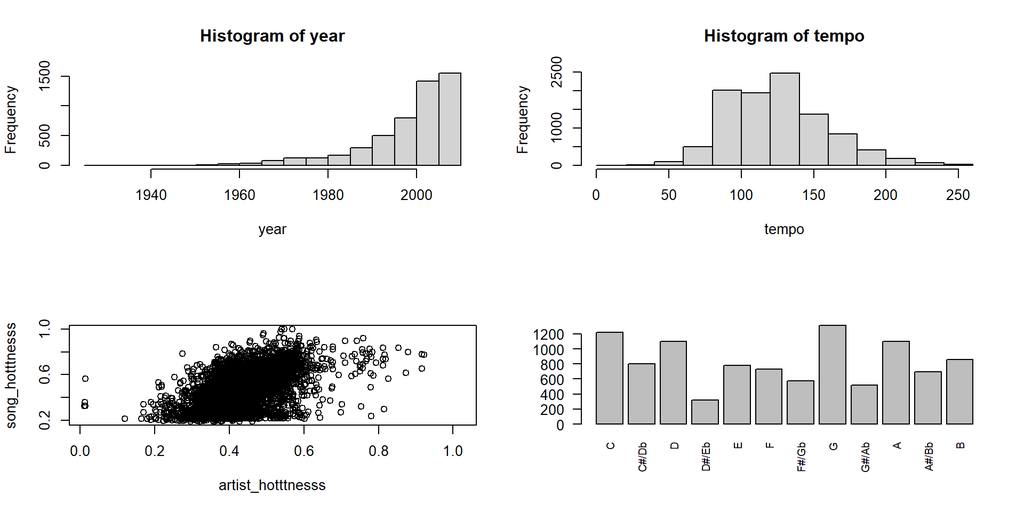

## Bivariate graphs

These are graphs which plot *two variables*. For continuous data, the simplest graph is a scatter plot which is made using the base `R` `plot()` function (when two numeric variables are provided), for example:

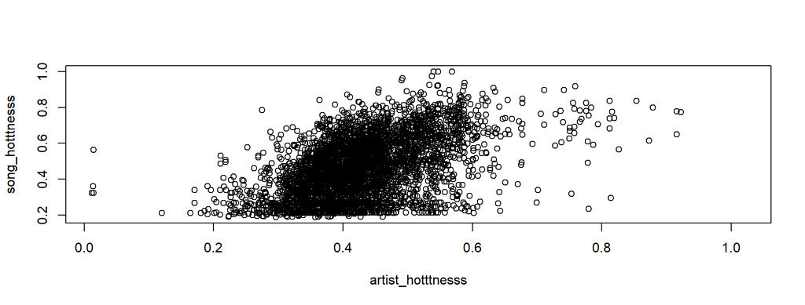

```r
plot(artist_hotttnesss, song_hotttnesss)
```

Artist hotness and song hotness seem highly related… but can use artist hotness to predict song hotness?

We pick up on this point in the regression.

## Dealing with larger amounts of data

The default scatter plot produced by `plot()` only works well when there is not a lot of overlap between the points on the graph.

When the number of observations is large, say `n > 1000`, over plotting begins to dominate. In this scenario the plot is a dense blob in which outliers and potentially interesting clusters get lost.

`R` has base plotting packages to help deal with this situation. You might discover other non-base `R` packages on your own which deal with this situation differently.

## `smoothScatter()`

The `smoothScatter()` reveals structure with a colour coded heat map.

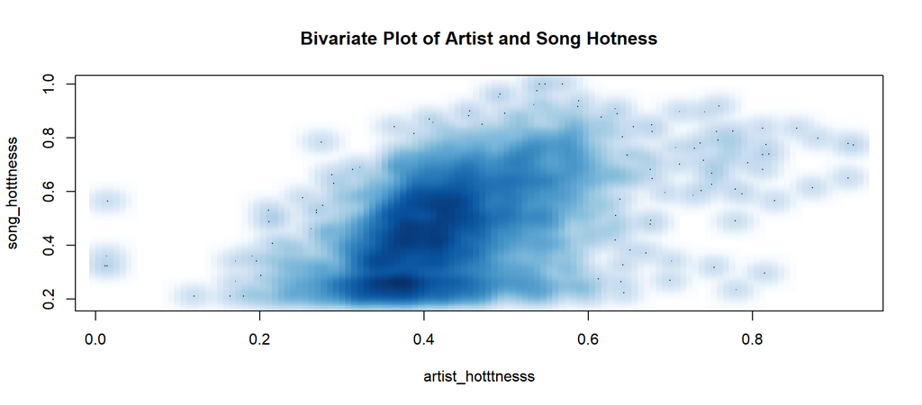

```r
smoothScatter(artist_hotttnesss, song_hotttnesss, main="Bivariate Plot of Artist and Song Hotness")
```

## Enhancing visualisations using AI

Copilot prompt: *“Create a smoothScatter plot of artist hotttnesss vs song hotttnesss using the MSD dataset. Add quadrant reference lines at 0.5, and highlight example artists and songs from each quadrant.”*

The code works and generates an engaging plot which communicates with impact, although the number of lines needed to produce this plot would not present well in a real business analytics report nor is seeing the plot code useful (it does not inform the reader how the analysis was conducted). Hence, we would normally set `echo = FALSE` in an instance like this.

## Using AI in your report

You are encouraged to use AI to modify and enhance the aesthetics of basic plots. This will demonstrate your ability to use AI *constructively* the purpose of generating a data visualisation designed for impact and clear interpretation.

Ensure you understand the code generated by AI and can explain it in your report. You should also be able to modify the code to suit your needs, e.g., to change the variables plotted. The types of plots you use should not be determined by AI, but rather by your own judgement about which types visualisations covered in this course are best suited to the data and the insights you want to communicate whilst also staying within scope of the course content.

## Example: AI code generated visualisation

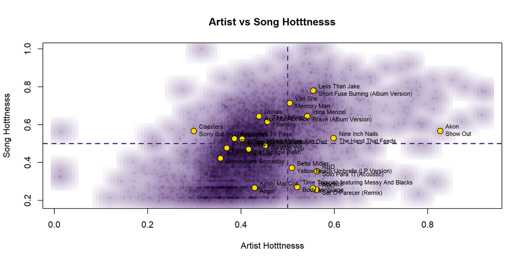

## Visualising contingency distributions

Table objects when plotted with `barplot()` will produce a stacked plot. With some basic formatting applied, such plots complement contingency tables to communicate this information more effectively.

```r
table(mode, key) |>
  barplot(
  col = c("skyblue", "orange"),
  border = "white",
  main = "Mode–Key Distribution",
  xlab = "Key",
  ylab = "Frequency",
  las = 2,
  cex.names = 0.8
)

legend(
  "topright",
  legend = c("Minor", "Major"),
  fill = c("skyblue", "orange"),
  horiz = TRUE
)
```

## Visualising contingency distributions

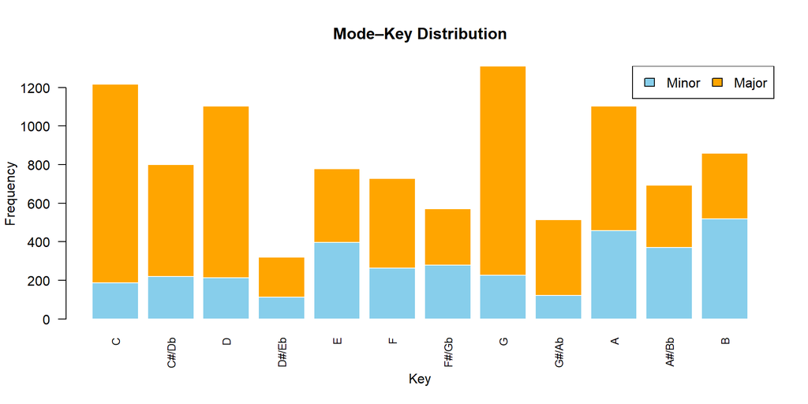

## Highlighting key insights

When interpreting descriptive statistics and visualisations, focus on patterns that reveal something meaningful, unexpected, or actionable.

For example, we saw earlier that artist hotness and song hotness appear to be strongly associated but is this useful information for prediction? Consider whether artist and song hotness are actually the same thing or whether you would repliable know what a artists hotness score is (especially for new artists)

Not every number is an insight, and not every strong or significant relationship is interesting.

## Demonstrating a high level of understanding

To achieve a high score on your report you need to clearly explain the code used and provide concise interpretations of the outputs generated.

The narrative text should connect the code to the broader purpose of the report and show an awareness of how their decisions during the *Data Processing* section may link to or affect the analysis in this section.

The narrative text should not read like a mechanical line by line commentary on the code, it should feel like a thoughtful walkthrough of the project from start to finish.

## Where to from here?

You have now covered the bases needed to get started on the *Exploratory Analysis* section of the report.

Outside of class you should carefully adapt the code covered here into your `.Rmd` file. Go slowly, taking time to convince yourself you understand the logic behind the code.

Thank you!